# Report for spearman using the fitted method

Jory Curry

25 November 2022

# 1 Toxicology Behavioural Analysis Report

## 1.1 Version Control

```r
# - My Machine Info:
#   - R version 4.2.1 (2022-06-23)
#   - Platform: x86_64-pc-linux-gnu (64-bit)         5.11.0-34-generic / Ubuntu 22.04.1 LTS
#   - Desktop: GNOME 3.36.5
#   - Hardware: CPU - Intel Core i5-9400F 6 core 4.1GHz / RAM - 15924MiB
```

## 1.2 Similarity Scores/Correlation coefficients

### 1.2.1 Benchmark Dose

Since we do not know what the benchmark response is for each one of the chemicals, a method will be used that can estimate a benchmark response (empirically) when given a large enough set of data. The RcurveP package includes an automated process to select an appropriate BMR based off of the data. From Hsieh et al. 2019 manuscript: “The pooled variance of potency of all chemicals per [threshold value (i.e. 5 through 99)] was calculated. The BMR was considered as the [threshold value] at which the potency variance was sufficiently reduced and was the lowest threshold that potency variance was stabilized”. AKA, “the lowest threshold (which gives the highest potency), at which a decrease of variance in potency estimation is stabilized”

#### 1.2.1.1 Negative Direction

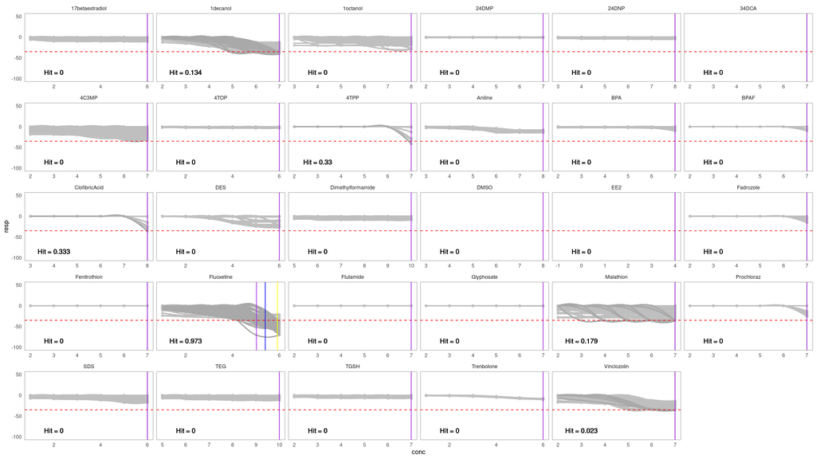

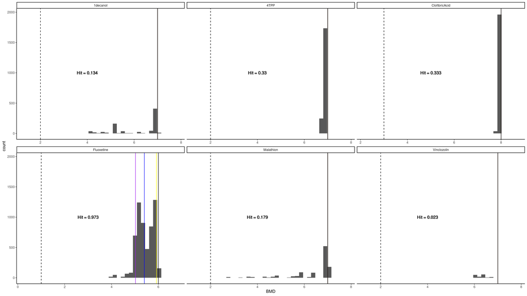

Table 9. Summary of all the benchmark doses (BMDs) of every chemical

| Chemical | endpoint | Low Dose (mg/L) | High Dose (mg/L) | BMD - low confidence interval (0.05) | BMD | BMD - high confidence interval (0.95) | Hit Confidence |
| --- | --- | --- | --- | --- | --- | --- | --- |
| 17betaestradiol | spearman_fitted | 0.0000100 | 0.1000000 | 0.1000000 | 0.1000000 | 0.1000000 | 0.000 |
| 1decanol | spearman_fitted | 0.0001000 | 1.0000000 | 1.0000000 | 1.0000000 | 1.0000000 | 0.134 |
| 1octanol | spearman_fitted | 0.0010000 | 10.0000000 | 10.0000000 | 10.0000000 | 10.0000000 | 0.000 |
| 24DMP | spearman_fitted | 0.0001000 | 1.0000000 | 1.0000000 | 1.0000000 | 1.0000000 | 0.000 |
| 24DNP | spearman_fitted | 0.0010000 | 10.0000000 | 10.0000000 | 10.0000000 | 10.0000000 | 0.000 |
| 34DCA | spearman_fitted | 0.0001000 | 1.0000000 | 1.0000000 | 1.0000000 | 1.0000000 | 0.000 |
| 4C3MP | spearman_fitted | 0.0001000 | 1.0000000 | 1.0000000 | 1.0000000 | 1.0000000 | 0.000 |
| 4TOP | spearman_fitted | 0.0000100 | 0.1000000 | 0.1000000 | 0.1000000 | 0.1000000 | 0.000 |
| 4TPP | spearman_fitted | 0.0001000 | 1.0000000 | 1.0000000 | 1.0000000 | 1.0000000 | 0.330 |
| Aniline | spearman_fitted | 0.0010000 | 10.0000000 | 10.0000000 | 10.0000000 | 10.0000000 | 0.000 |
| BPA | spearman_fitted | 0.0001000 | 1.0000000 | 1.0000000 | 1.0000000 | 1.0000000 | 0.000 |
| BPAF | spearman_fitted | 0.0001000 | 1.0000000 | 1.0000000 | 1.0000000 | 1.0000000 | 0.000 |
| ClofibricAcid | spearman_fitted | 0.0010000 | 10.0000000 | 10.0000000 | 10.0000000 | 10.0000000 | 0.333 |
| DES | spearman_fitted | 0.0000100 | 0.1000000 | 0.1000000 | 0.1000000 | 0.1000000 | 0.000 |
| Dimethylformamide | spearman_fitted | 0.1000000 | 1000.0000000 | 1000.0000000 | 1000.0000000 | 1000.0000000 | 0.000 |
| DMSO | spearman_fitted | 0.0010000 | 10.0000000 | 10.0000000 | 10.0000000 | 10.0000000 | 0.000 |
| EE2 | spearman_fitted | 0.0000001 | 0.0010000 | 0.0010000 | 0.0010000 | 0.0010000 | 0.000 |
| Fadrozole | spearman_fitted | 0.0001000 | 1.0000000 | 1.0000000 | 1.0000000 | 1.0000000 | 0.000 |
| Fenitrothion | spearman_fitted | 0.0001000 | 1.0000000 | 1.0000000 | 1.0000000 | 1.0000000 | 0.000 |
| Fluoxetine | spearman_fitted | 0.0000100 | 0.1000000 | 0.0105619 | 0.0264981 | 0.0831236 | 0.973 |
| Flutamide | spearman_fitted | 0.0001000 | 1.0000000 | 1.0000000 | 1.0000000 | 1.0000000 | 0.000 |
| Glyphosate | spearman_fitted | 0.0001000 | 1.0000000 | 1.0000000 | 1.0000000 | 1.0000000 | 0.000 |
| Malathion | spearman_fitted | 0.0001000 | 1.0000000 | 1.0000000 | 1.0000000 | 1.0000000 | 0.179 |
| Prochloraz | spearman_fitted | 0.0001000 | 1.0000000 | 1.0000000 | 1.0000000 | 1.0000000 | 0.000 |
| SDS | spearman_fitted | 0.0000100 | 0.1000000 | 0.1000000 | 0.1000000 | 0.1000000 | 0.000 |
| TEG | spearman_fitted | 0.1000000 | 1000.0000000 | 1000.0000000 | 1000.0000000 | 1000.0000000 | 0.000 |
| TGSH | spearman_fitted | 0.0001000 | 1.0000000 | 1.0000000 | 1.0000000 | 1.0000000 | 0.000 |
| Trenbolone | spearman_fitted | 0.0000100 | 0.1000000 | 0.1000000 | 0.1000000 | 0.1000000 | 0.000 |
| Vinclozolin | spearman_fitted | 0.0001000 | 1.0000000 | 1.0000000 | 1.0000000 | 1.0000000 | 0.023 |